# Stochastic Process

Supplemental notes for lecture 1, U20 Math 585

Sami Cheong

9/8/2020

```r
knitr::opts_chunk$set(echo = TRUE)
library(ggplot2)
library(randomcoloR)
```

## Comparing between deterministic and stochastic modeling - simple growth modeling

Consider the modeling of the size of a population at time $t$, let’s call this quantity $x(t),$ and suppose we have the following assumptions:

- there are no deaths in the population
- there are no interactions between individuals
- each individual has the same birth rate $b$
- at time $t = 0,$ the population is $a > 0$

### Deterministic formulation:

We can model $x(t)$ by modeling it’s rate of change, as a function of itself:

$\frac{dx}{dt} = bx,x_0 = x(0) = a$

$\int dx(t) = \int bx(t) dt$

The only function that satisfy the above relation is if $x(t) = e^{bt}.$ Therefore:

$x = a e^{bt},$ where $a > 0 $ = initial population, $x(0)$, and $b > 0$ = birth rate

Below is a visualization of the population over time with some assumption for $a$ and $b$:

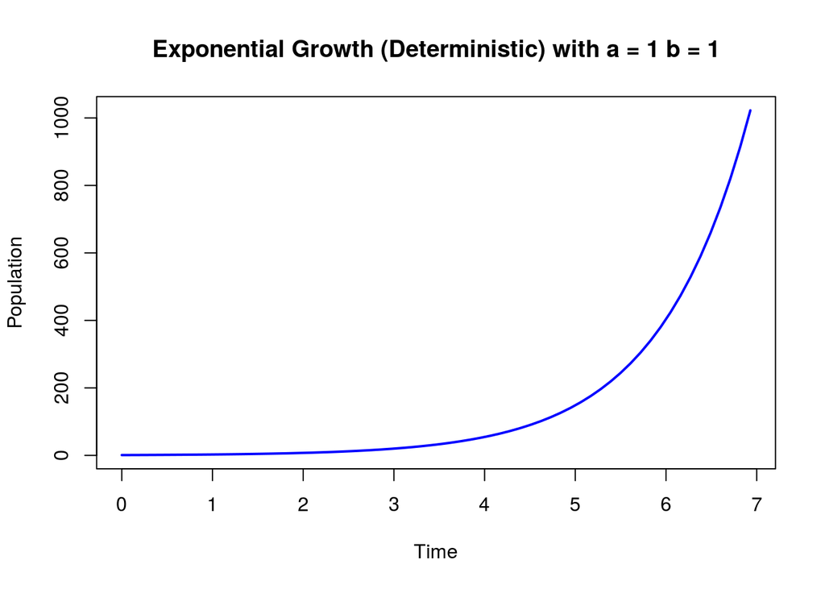

```r
t  = seq(from = 0, to = 7,by = 0.11)
a = 1
b = 1
x =  a*exp(b*t)
plot(t,x,type = 'l', col = 'blue',lwd = 2,
     main = paste('Exponential Growth (Deterministic) with a =', a, 'b =', b ),
     xlab = 'Time',
     ylab = 'Population')
```

### Stochastic formulation:

In the stochastic case, we are interested in the *Probability* that our population at time $t$ is at a some quantity. Mathematically, that is defined as
$$p_n(t) = \mathbb{P}(x(t)=n).$$

THis means that, instead of modeling $\frac{dx}{dt}$, the rate of change of the population, we model the rate of change of the probability, $\frac{dp_n(t)}{dt},$ and our goal here is to solve for $p_n(t)$.

One approach is the assumption that the population equations $n$ at time $t + \Delta t$ is a one of these two events:

- at time $t$ the population size was $n - 1$ and there was a birth
- at time $t$ the population size was $n$ and there was no birth

which can be formulated as :

$$p_n(t+\Delta t) = \underbrace{p_{n-1}(t)}_{\text{prob. that size} = n-1}\overbrace{b(n-1)\Delta t}^{\text{new birth}} + \underbrace{p_n(t)}_{\text{prob. that size = n}}\overbrace{(1 - b n \Delta t)}^{\text{ no new birth}}$$

subtracting $p_n(t)$ from both side, divide by $\Delta t$ and letting $\Delta t \to 0,$ we get the following differential equation:

$$\frac{p_n(t)}{dt} = b(n-1)p_{n-1}(t) - bnp_n(t)$$

where $n = 1, 2, \dots$. It turns out, at each fixed time $t$, $p_n(t)$ follows the negative binomial distribution with the following parameters:

$$p_n(t) = {n-1 \choose {a-1}} e^{-abt} (1=e^{-bt})^{n-a}, n = a, a+1, a+2, \dots$$

Now, to simulate a sample path based on the above assumption, we need to know the distribution of the time between successive birth events, or its *interenvet* time. It turns out in the case of a simple birth process (Stochastic counterpart of exponential growht model), the interevent time is *exponentially distributed* with rate $bn.$ In other words, if $T$ represents the time it takes to go from one birth event to next, then $T$ is a random variable with a distribution that satisfies:
$$\mathbb{P}(T>t) = \exp(-bnt), t > 0$$

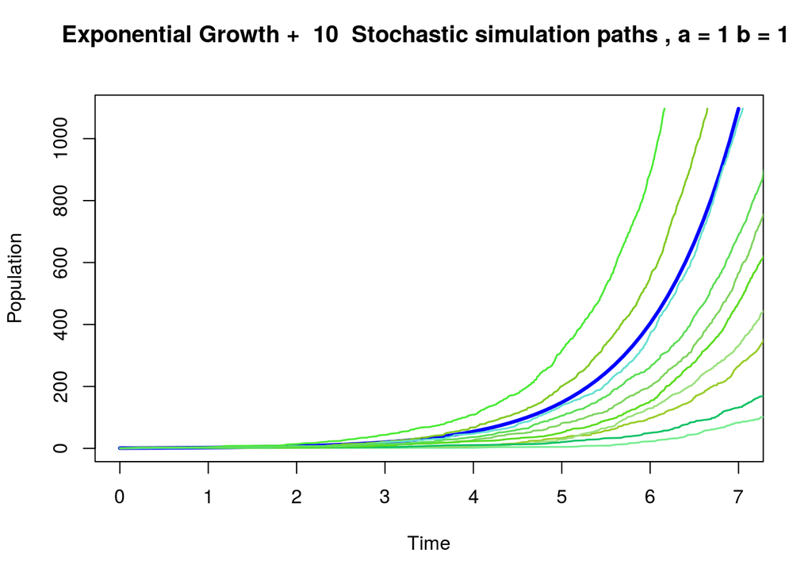

```r
stoch_time <- function(n, b){
  st <- rep(0,length(n))

  for (i in 1: (length(n)-1)){

    st[i+1] <- st[i] - log(runif(1))/(b*n[i])
  }
  return(st)
}


# simulation sample paths:
t <- seq(0,7,0.1)
a <-1
b <- 1

# generate a number of realizations:
n_try <- 10
n_max <- max(ceiling(exp(b*t)))

plot(t,exp(b*t),type = 'l', col = 'blue',lwd = 3,
     main = paste('Exponential Growth + ' ,n_try, ' Stochastic simulation paths , a =', a, 'b =', b ,'\n'),
     xlab = 'Time',
     ylab = 'Population')


for (i in 1:n_try){

  lines(stoch_time(n = seq(a,n_max,1),1),seq(a,n_max,1), col = randomColor(hue = 'green'), lwd = 1.5)
}
```

### Example 2: Random Walk

- Suppose you have some change (`$k`) and you’d like to see if you could get to `$n` by betting with a friend on a coin toss.
- Each time you flip a coin dictates whether or not you’re gain $1, or lose $1.

Let $X_i, i = 1,2, 3,...$ be such an event. Note that $\{𝑋_𝑖\}_{i=1}^\infty$ is a sequence of i.i.d. random variables and

- $𝑋_𝑖= +1$ with probability p
- $𝑋_𝑖=−1$ with probability q = 1-p

Now suppose $𝑆_𝑛=𝑋_1+𝑋_2+⋯+𝑋_𝑛$ is the amount of dollars you have left after n turns. You will not stop until you either get $n or lost all your change.

*What is $\mathbb{P}(S_n = 0)$?*

Let’s define some functions to help us find the answer by simulation.

```r
X_k <- function(p) {
  # function to generate a random step:
  return(sample(c(-1,1),1,prob=c(1-p,p)))

}

random_path <- function(p,k,n){
  # function to simulate a path:

  X <- replicate(n, X_k(p))

  return(cumsum(X)+k)


}

random_path(0.5,0,10)
```

```
##  [1] 1 0 1 2 1 2 3 4 5 6
```

```r
#S_n == X_1 + X_2 + X_3 + ...+ X_n given I have a budget of k and a goal of $n

gamble <- function(k,n,p) {
  # function to simulate a gambling game
  # for a given budget, desired $ and prob of +1 at each step
  stake <- k

  while (stake > 0 & stake < n) {

    bet <- sample(c(-1,1),1,prob=c(1-p,p))

    stake <- stake + bet
  }
  if (stake == 0) return(1) else return(0)
}
```

```r
# simulate probability of P(Sn = 0)
k <- 0
n <-  100
p <- 0.5
trials <- 1
simlist <- replicate(trials, gamble(k, n, p))
# Estimate of probability that gambler is ruined
# For p = 0.5, exact probability is (n-k)/n
mean(simlist)
```

```
## [1] 1
```

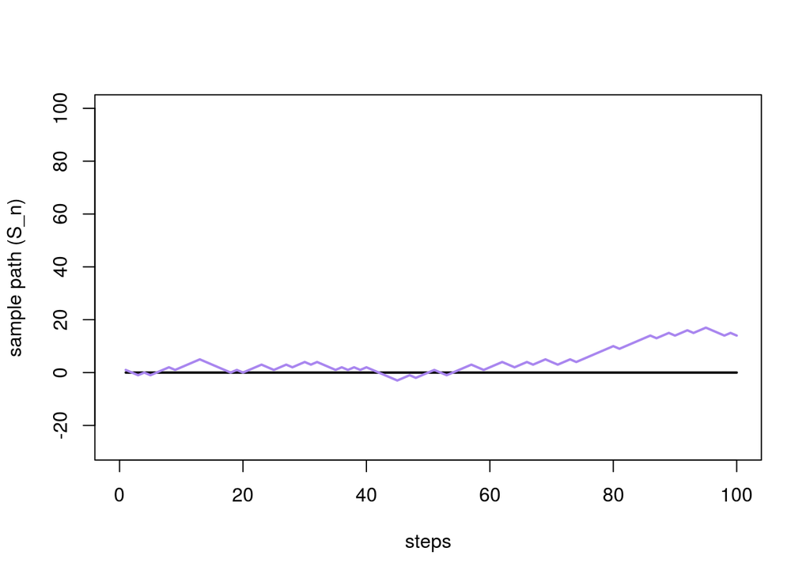

```r
# simulate sample paths of random walks after n steps:
random_paths <- list()
max_vals <- NULL
min_vals <- NULL
for (i in 1:n){
  random_paths[[i]] <- random_path(p,k,n)
  max_vals <- c(max_vals,max(random_paths[[i]]))
  min_vals <- c(min_vals,min(random_paths[[i]]))
}

max_val <- max(max_vals)
min_val <- min(min_vals)
ymin = min(-10, min_val - 2)
ymax = max(n, max_val + 2)
xlab = 'steps'
ylab = 'sample path (S_n)'

plot(seq(1,n,1), rep(k,n),xlim = c(0,n), ylim = c(ymin,ymax), type ='l',lwd =2, xlab= xlab, ylab = ylab)
#lines(seq(1,n,1), rep(0,n),xlim = c(0,n), ylim = c(ymin,ymax),  col='red',lwd =3, xlab= xlab, ylab = ylab)
#lines(seq(1,n,1), rep(n,n),xlim = c(0,n),ylim = c(ymin,ymax),  col='forestgreen', lwd = 3, xlab= xlab, ylab = ylab)

for (i in 1:trials){
  lines(seq(1,n,1), random_paths[[i]], col = randomColor(hue = 'purple'),lwd =2)

}
```

Let’s try to simulate $S_n$ as a function of n:

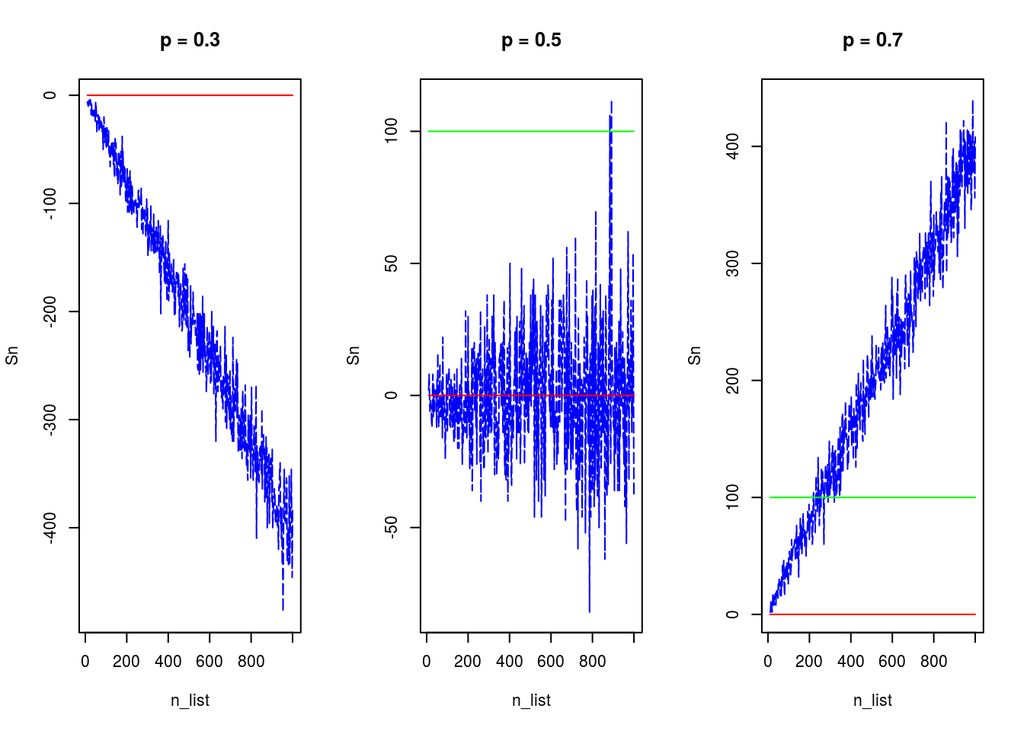

```r
# simulate gambler's sum as a function of n:
n_list <- seq(k+10, k+ 1000,2)
par(mfrow = c(1,3))
p<- 0.3
Sn <- unlist(lapply(n_list, function(n){random_path(p,k,n)[n]}))
plot(n_list,Sn,type ='l', col = 'blue',lty =5, main = 'p = 0.3')
lines(n_list, rep(0,length(n_list)),col = 'red',)
lines(n_list, rep(n,length(n_list)),col = 'green', ylim = c(-100,100))

p<- 0.5
Sn <- unlist(lapply(n_list, function(n){random_path(p,k,n)[n]}))
plot(n_list,Sn,type ='l', col = 'blue',lty =5, main = 'p = 0.5')
lines(n_list, rep(0,length(n_list)),col = 'red',)
lines(n_list, rep(n,length(n_list)),col = 'green',ylim = c(-100,100))


p<- 0.7
Sn <- unlist(lapply(n_list, function(n){random_path(p,k,n)[n]}))
plot(n_list,Sn,type ='l', col = 'blue',lty =5, main = 'p = 0.7')
lines(n_list, rep(0,length(n_list)),col = 'red',)
lines(n_list, rep(n,length(n_list)),col = 'green',ylim = c(-100,100))
```

### Distribution of well-known random variables:

Discrete examples:

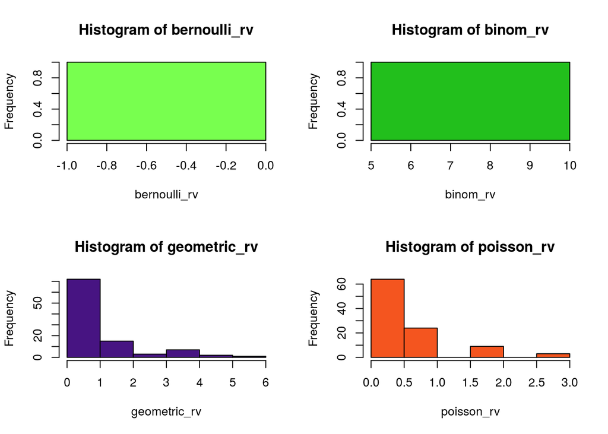

```r
p <- 0.5


bernoulli_rv <- replicate(trials, sample(c(0,1), 1, prob = c(p,1-p)))

binom_rv <- replicate(trials, rbinom(1,10,0.5))


geometric_rv = replicate(trials, rgeom(100,p))

poisson_rv = replicate(trials, rpois(100,0.5))

par(mfrow = c(2,2))

hist(bernoulli_rv, col = randomColor())
hist(binom_rv, col = randomColor())
hist(geometric_rv, col = randomColor())
hist(poisson_rv, col = randomColor())
```

Continuous examples:

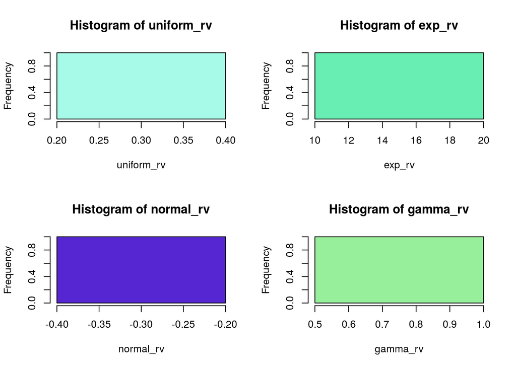

```r
p <- 0.5

a = 0
b = 10

uniform_rv <- replicate(trials, runif(1, a, b))

exp_rv <- replicate(trials, rexp(1,0.3))

normal_rv = replicate(trials, rnorm(1,0,1))

gamma_rv = replicate(trials, rgamma(1,2,1))

par(mfrow = c(2,2))

hist(uniform_rv, col = randomColor(),30)
hist(exp_rv, col = randomColor(),30)
hist(normal_rv, col = randomColor(),30)
hist(gamma_rv, col = randomColor(),30)
```